# “Quick Service Restaurant Market Opportunity Analysis”

## 4.2 Geographic Visualization

Interactive maps reveal spatial patterns in market opportunities:

This report shows representative screenshots from the live Shiny app for consistency and reproducibility. **See the live interactive maps here:** [live Shiny app](https://o8hxxy-stephanie-grier.shinyapps.io/metro_map_app/).

[figure not shown]

[figure not shown]

**Geographic Insight:** Opportunity zones cluster in suburban areas with growing populations but limited QSR infrastructure, suggesting expansion opportunities in emerging neighborhoods.

## 4.3 Food-Type Analysis

Drilling down to specific food categories reveals which restaurant types show the strongest opportunity signals within each metro:

This report shows representative screenshots from the live Shiny app for consistency and reproducibility.  
**See the live interactive food type charts here:** [live Shiny app](https://o8hxxy-stephanie-grier.shinyapps.io/food_charts_app/)

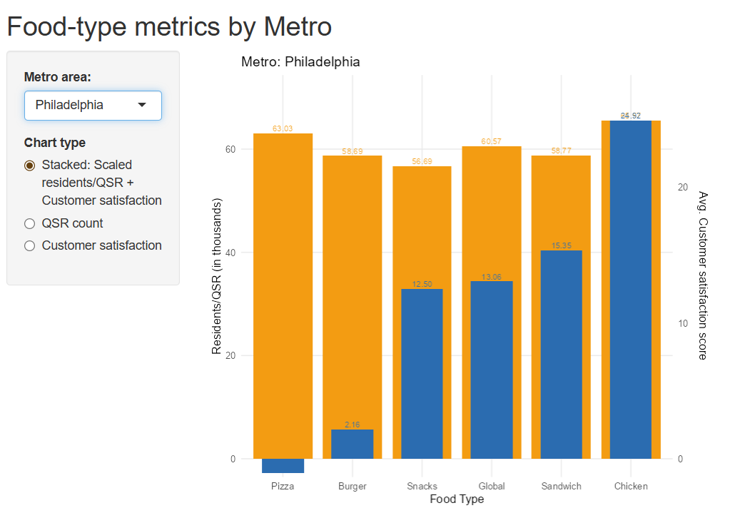

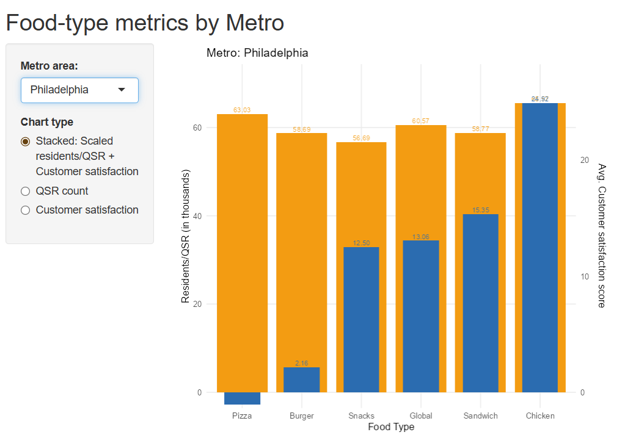

This granular analysis transforms insights from “Philadelphia has opportunities” to “Philadelphia has pizza opportunities specifically” - actionable intelligence for entrepreneurs.

## 4.4 Operational Attribute Correlation Analysis

Which operational features correlate with customer satisfaction? I analyzed various business attributes across all metros:

This report shows representative screenshots from the live Shiny app for consistency and reproducibility. **See the live interactive Pearson Correlation Heatmaps here:** [live Shiny app](https://o8hxxy-stephanie-grier.shinyapps.io/final_correlation_app/).

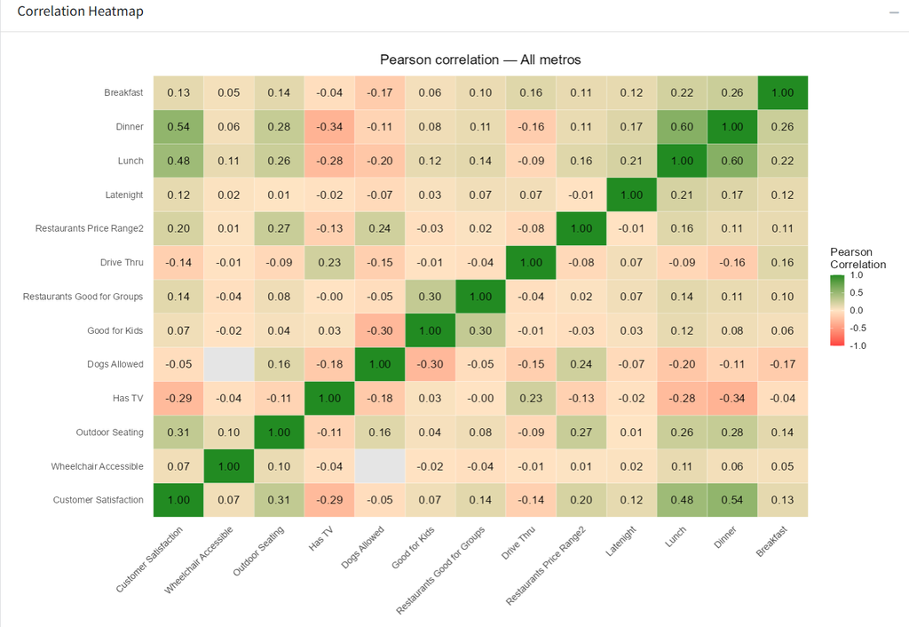

### The Drive-Thru Paradox

The negative correlation between drive-thrus and satisfaction warrants deeper discussion. This doesn’t mean customers don’t want drive-thrus - 40% of QSR sales flow through them. Rather, drive-thrus create a paradox of expectations:

- **Success = Meeting expectations** (no extraordinary review)
- **Failure = Magnified disappointment** (wasted time, the resource customers sought to save)

**Implication:** Drive-thrus must be executed flawlessly or skipped entirely. A mediocre drive-thru is worse than no drive-thru at all.

# 5. Business Recommendations

Based on this analysis, I would advise QSR entrepreneurs as follows:

## Food-Type Specific Recommendations

[output not shown]

## Operational Priorities

1. **Drive-thru excellence or avoidance** - no middle ground
2. **Outdoor seating** where climate permits (particularly Tampa, St. Louis)
3. **Breakfast offerings** to capture morning daypart
4. **Price positioning** aligned with local market expectations

# 6. Limitations & Future Work

## Limitations

- **Temporal:** Analysis represents a snapshot; markets evolve rapidly
- **Review bias:** Yelp users may not represent all customer segments
- **Geographic:** Analysis limited to 10 metros, may not generalize nationally
- **Causation:** Correlations don’t establish causal relationships

## Future Research Directions

- **Predictive modeling:** Build models to forecast new location success probability
- **Competitive dynamics:** Analyze how new entrants affect existing businesses
- **Demographic deep-dive:** Incorporate income, age, education variables
- **Traffic patterns:** Integrate real-time traffic/mobility data
- **Expansion sequencing:** Optimal order for multi-location rollouts

# 7. Technical Appendix

## 7.1 Data Processing Pipeline

```r
# Complete data processing workflow
full_pipeline <- function(yelp_json, census_csv) {
  # Step 1: Parse and clean
  businesses <- parse_yelp_business(yelp_json)
  qsr_data <- filter_qsr(businesses)

  # Step 2: Classify food types
  qsr_data <- qsr_data %>%
    mutate(food_type = classify_food_type(categories))

  # Step 3: Join demographics
  qsr_data <- qsr_data %>%
    left_join(read_csv(census_csv), by = "postal_code")

  # Step 4: Calculate metrics
  qsr_data <- calculate_market_metrics(qsr_data)

  # Step 5: Classify opportunities
  qsr_data <- classify_opportunities(qsr_data)

  return(qsr_data)
}
```

# 8. Conclusion

This analysis demonstrates how publicly available data can generate actionable business intelligence for restaurant site selection. By combining demographic data with customer feedback at granular geographic levels, we can identify specific opportunities that traditional market research might overlook.

The framework developed here - identifying the intersection of high demand and low satisfaction, then drilling down to food-type specifics - provides a replicable methodology for analyzing expansion opportunities across industries beyond QSR.

**Key Takeaway:** Data-driven site selection transforms entrepreneurial risk from gamble to calculated strategy, increasing the probability of success while revealing opportunities competitors may miss.

*Interactive dashboards and additional visualizations available at: [https://stephaniejgrier.github.io]*

*Full code repository: [https://github.com/stephaniejgrier/Yelp_Case-_Study]*